# Harmful Weather Events in Health and the Economy

26-02-2021

# 1 Synopsis

Storms and other severe weather events can cause both public health and economic problems for communities and municipalities. Many severe events can result in fatalities, injuries, and property damage, and preventing such outcomes to the extent possible is a key concern. This project involves exploring the U.S. National Oceanic and Atmospheric Administration’s (NOAA) storm database. This database tracks characteristics of major storms and weather events in the United States, including when and where they occur, as well as estimates of any fatalities, injuries, and property damage. The two main questions to answer are: Across the United States, which types of events (as indicated in the EVTYPE variable) are most harmful with respect to population health? Across the United States, which types of events have the greatest economic consequences?

First we will briefly process the data. The dataset contains almost a million rows starting in 1950 until 2011. So we will need to subset it, using only the important data. The main results obtained from the analysis of the data are presented in the section “Results”.

# 2 Data Processing

First we will start by reading the data. The dataset can be found in the following link: [Dataset](https://d396qusza40orc.cloudfront.net/repdata%2Fdata%2FStormData.csv.bz2). Also, we will load the libraries that will be used. The libraries used are: ggplot2, dplyr,grid,gridExtra. Finally, let’s watch at the dimmension of the data.

```r
stormdata <- read.csv("stormdata.csv.bz2",header = TRUE,stringsAsFactors = FALSE)
dim(stormdata)
```

```
## [1] 902297     37
```

```r
library(ggplot2)
library(dplyr)
library(grid)
library(gridExtra)
```

Before doing anything, we are going to check a simple histogram of the data present by year. We are going to check which years have had more storms, in order to subset those and focus our analysis over there. Since there is a lot of data, it is important to subset and reduce the amount of rows, if possible.

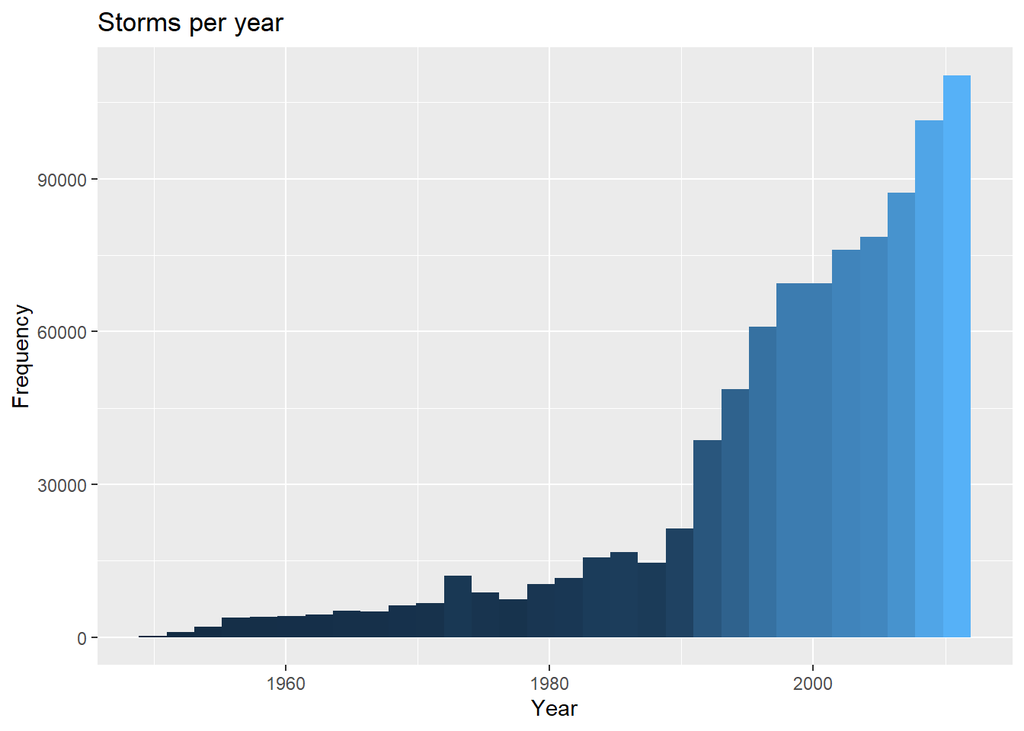

```r
# First we create a new column that contains the year in which the event occured
stormdata$year <- as.numeric(format(as.Date(stormdata$BGN_DATE,format = "%m/%d/%Y %H:%M:%S"),"%Y"))
hist_plot <- ggplot(stormdata,aes(x=year)) + geom_histogram(bins = 30,aes(y=..count..,fill=..count.. )) +
    labs(title = "Storms per year",x="Year",y = "Frequency") + theme(legend.position = "none")
hist_plot
```

We see that since nearly 1995 there are more storms, also, the data is more complete in those years (i.e, less missing values). So I will subset the data from 1995 until 2011, the latest data available. Also, we will subset the data only with the important columns. Those are the columns that contain relevant information about the type of the event, and their health and economic consequences.

```r
subset_data <- stormdata[stormdata$year >= 1995,]
subset_data <- subset_data[,c("BGN_DATE","EVTYPE","FATALITIES","INJURIES","PROPDMG","PROPDMGEXP",
                               "CROPDMG","CROPDMGEXP","year")]
dim(subset_data)
```

```
## [1] 681500      9
```

Now we have about 220,000 rows less.

Next, we will try and clean a bit the data. “EVTYPE” variable means “Event type”, you can notice (I will not do it because the result is to extense) that there are to many different Event types. In the following [PDF](https://d396qusza40orc.cloudfront.net/repdata%2Fpeer2_doc%2Fpd01016005curr.pdf) you can find out that only 48 of them are considered “officials” in the dataset there are a lot of mistakes (such as typos or differences between Upper case and lower case words). Considering that, we will create a character list that contains only the 48 official events and subset our data to the rows that contain those events. Also, we will make all the words Upper case, to avoid on more problem.

```r
subset_data$EVTYPE <- toupper(subset_data$EVTYPE)
eventnames <- c("Astronomical Low Tide","Avalanche","Blizzard","Coastal Flood","Cold/Wind Chill",
                "Debris Flow","Dense Fog","Dense Smoke","Drought","Dust Devil","Dust Storm","Excessive Heat",
                "Extreme Cold/Wind Chill","Flash Flood","Flood","Frost/Freeze","Funnel Cloud","Freezing Fog","Hail",
                "Heat","Heavy Rain","Heavy Snow","High Surf","High Wind","Hurricane (Typhoon)","Ice Storm",
                "Lake-Effect Snow","Lakeshore Flood","Lightning","Marine Hail","Marine High Wind","Marine Strong Wind",
                "Marine Thunderstorm Wind","Rip Current","Seiche","Sleet","Storm Surge/Tide","Strong Wind",
                "Thunderstorm Wind","Tornado","Tropical Depression","Tropical Storm","Tsunami","Volcanic Ash",
                "Waterspout","Wildfire","Winter Storm","Winter Weather")

eventnames <- toupper(eventnames)
subset_data <- subset_data[subset_data$EVTYPE %in% eventnames,]
dim(subset_data)
```

```
## [1] 519244      9
```

Now we have **almost 400,000 (in total) rows less!**

In the next subsection, we will try to process the data and leave it ready to answer the questions raised in the synopsis.

## 2.1 Data Processing: Which types of events are the most harmful with respect to population health?

In this subsection we will try to use the data in order to response the question raised. First a new variable called “harmful_events” will be created. This variable contains the total amount of “fatalities” and “injuries” that each type of event has caused. We will consider only those events that have at least 10 fatalities or injuries in total in the years selected, since a lot of them do not have big consequences.

```r
harmful_events <- aggregate(x = data.frame(subset_data$FATALITIES,subset_data$INJURIES),by = list(subset_data$EVTYPE), FUN = "sum")
names(harmful_events) <- c("EVTYPE","FATALITIES","INJURIES")
harmful_events <- harmful_events[harmful_events$FATALITIES > 10 | harmful_events$INJURIES > 10,]
head(harmful_events)
```

```
##             EVTYPE FATALITIES INJURIES
## 2        AVALANCHE        223      159
## 3         BLIZZARD         71      385
## 5  COLD/WIND CHILL         95       12
## 6        DENSE FOG         10      276
## 9       DUST DEVIL          2       43
## 10      DUST STORM         21      420
```

```r
dim(harmful_events)
```

```
## [1] 31  3
```

We can see that only 31 (of the 48 type of events) have at least 10 fatalities or injuries. Next, we will order the data and subset it to only the 10 events with more consequences. This will be stored in “order_data”.

```r
order_data <- harmful_events
order_data$fat_inj <- order_data$FATALITIES + order_data$INJURIES
order_data <- order_data[order(order_data$fat_inj,decreasing = TRUE),]
order_data <- order_data[1:10,]
```

With this data, we are ready to plot and answer the question raised above, but we will do that in the “Result” section.

## 2.2 Data Processing: Which types of events have the greatest economic consequences?

In this subsection, we will try to use the data in order to response the second question raised. To measure the economic consequences, we can use the variables “PROPDMG” (Property Damage),“PROPDMGEXP”(Property Damage Exponent),“CROPDMG” (Crop Damage) and “CROPDMGEXP” (Crop Damage Exponent). The Property and Crop Damage Exponents are the exponents for the Property and Crop Damage Exponents, but the values of the exponents are not always intuitive, as we can see now:

```r
unique(subset_data$PROPDMGEXP)
```

```
##  [1] ""  "K" "M" "0" "5" "m" "2" "4" "+" "7" "-" "?" "3" "1" "8" "H" "B"
```

As we can see, we have to work out this data to analyze it. The following lines of code will transform the Exponents variable in a numeric one. This transformation is based in an article about [How to handle Exponent Value](https://rstudio-pubs-static.s3.amazonaws.com/58957_37b6723ee52b455990e149edde45e5b6.html)

```r
# First the Property Damage Exponent
subset_data$PROPDMGEXP <- as.character(subset_data$PROPDMGEXP)
subset_data$PROPDMGEXP[subset_data$PROPDMGEXP %in% c("0","1","2","3","4","5","6","7","8")] <- 10
subset_data$PROPDMGEXP[subset_data$PROPDMGEXP %in% c("?","-"," ","")] <- 0
subset_data$PROPDMGEXP[subset_data$PROPDMGEXP %in% c("+")] <- 1
subset_data$PROPDMGEXP[subset_data$PROPDMGEXP %in% c("H","h")] <- 100
subset_data$PROPDMGEXP[subset_data$PROPDMGEXP %in% c("K","k")] <- 1000
subset_data$PROPDMGEXP[subset_data$PROPDMGEXP %in% c("M","m")] <- 1000000
subset_data$PROPDMGEXP[subset_data$PROPDMGEXP %in% c("B","b")] <- 1000000000
subset_data$PROPDMGEXP <- as.numeric(subset_data$PROPDMGEXP)
#Now the Crop Damage Exponent
subset_data$CROPDMGEXP <- as.character(subset_data$CROPDMGEXP)
subset_data$CROPDMGEXP[subset_data$CROPDMGEXP %in% c("0","1","2","3","4","5","6","7","8")] <- 10
subset_data$CROPDMGEXP[subset_data$CROPDMGEXP %in% c("?","-"," ","")] <- 0
subset_data$CROPDMGEXP[subset_data$CROPDMGEXP %in% c("+")] <- 1
subset_data$CROPDMGEXP[subset_data$CROPDMGEXP %in% c("H","h")] <- 100
subset_data$CROPDMGEXP[subset_data$CROPDMGEXP %in% c("K","k")] <- 1000
subset_data$CROPDMGEXP[subset_data$CROPDMGEXP %in% c("M","m")] <- 1000000
subset_data$CROPDMGEXP[subset_data$CROPDMGEXP %in% c("B","b")] <- 1000000000
subset_data$CROPDMGEXP <- as.numeric(subset_data$CROPDMGEXP)
```

Now, we can create a new variable that contains the total damage in property and crop, “TOTDMGPROP” & “TOTDMGCROP”. This is simply the multiplication between the Exponent and the damage value. We will also create a total damage variable, that is just the addition of the total property and crop damage.

```r
subset_data$TOTPROPDMG <- subset_data$PROPDMG * subset_data$PROPDMGEXP
subset_data$TOTCROPDMG <- subset_data$CROPDMG * subset_data$CROPDMGEXP
subset_data$TOTDMG <- subset_data$TOTPROPDMG + subset_data$TOTCROPDMG
```

With this done, we have a variable with an estimation of the total economic consequences of each event.

Next, we will create a new variable called “econ_dmg” that sums up the economic damage of each type of event. This will simply sum up the economic damage of each event.

```r
econ_dmg <- aggregate(subset_data$TOTDMG,list(subset_data$EVTYPE),FUN = "sum")
names(econ_dmg) <- c("EVTYPE","TOTDMG")
```

We will filter this variable only to those event types that have an economic damage bigger than 0. Next, we order the data decreasingly (i.e the event with the highest economic damage appears first), this will be done to filter only the 10 events with the highest economic damage.

```r
econ_dmg <- econ_dmg[econ_dmg$TOTDMG > 0,]
order_econ_dmg <- econ_dmg[order(econ_dmg$TOTDMG,decreasing = TRUE),]
order_econ_dmg <- order_econ_dmg[1:10,]
```

Now we have finished processing the data and we are ready to see some results.

# 3 Results

To respond the first question: Which types of events are the most harmful with respect to population health? We will plot the results of what we did in the section 2.1. Separating the health consequences by fatalities and injuries.

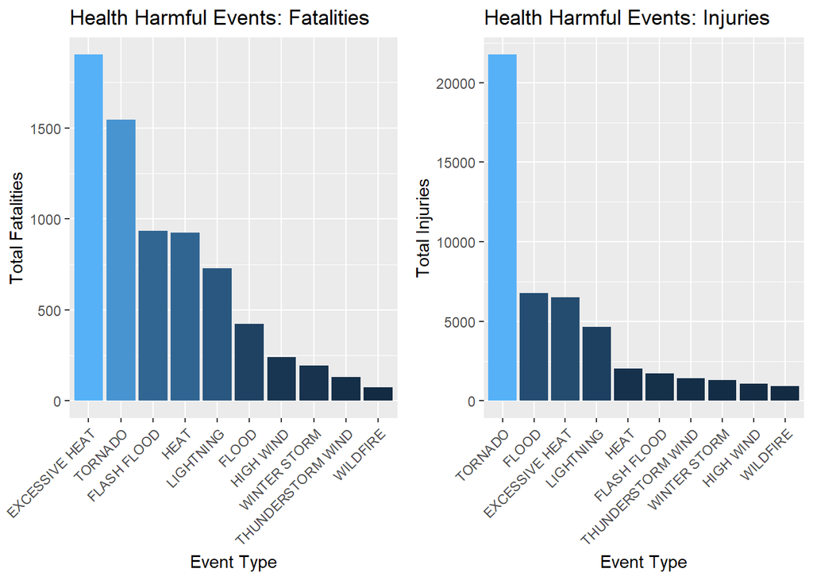

```r
q1_plot_fat <- ggplot(order_data, aes(x = reorder(factor(EVTYPE),-FATALITIES), y = FATALITIES)) +
    geom_bar(stat = "identity",aes(fill= FATALITIES)) + theme(legend.position = "none") +
    labs(title = "Health Harmful Events: Fatalities", x = "Event Type",
        y = "Total Fatalities") + theme(axis.text.x = element_text(angle = 45, hjust = 1))
q1_plot_inj <- ggplot(order_data, aes(x = reorder(factor(EVTYPE),-INJURIES), y = INJURIES)) +
    geom_bar(stat = "identity",aes(fill = INJURIES)) + theme(legend.position = "none") +
        labs(title = "Health Harmful Events: Injuries", x = "Event Type",
         y = "Total Injuries") + theme(axis.text.x = element_text(angle = 45, hjust = 1))
grid.arrange(q1_plot_fat,q1_plot_inj,ncol=2)
```

From this plot, we can conclude that Excessive Heat, Tornados and Floods are among the most harmful events. Although Tornados generate a really big amount of injuries.

To respond the second question: Which types of events have the greatest economic consequences? We will plot the results of what we did in the section 2.2. Using the total economic damage column as the relevant variable to answer the question.

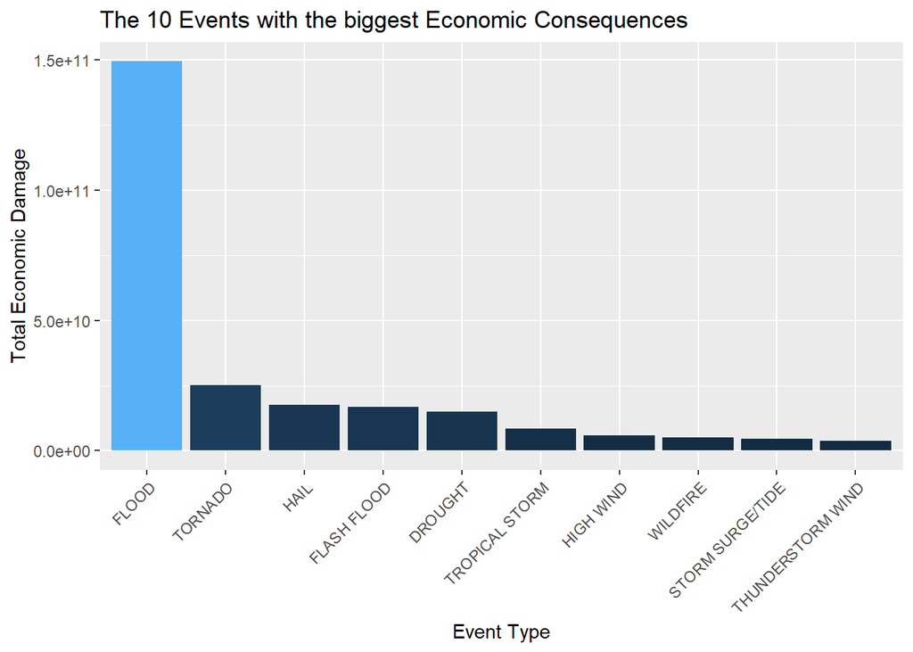

```r
q2_plot <- ggplot(order_econ_dmg, aes(x= reorder(factor(EVTYPE),-TOTDMG), y = as.numeric(TOTDMG))) +
    geom_bar(stat="identity",aes(fill= TOTDMG)) +theme(legend.position = "none") +
    labs(title = "The 10 Events with the biggest Economic Consequences", x = "Event Type", y = "Total Economic Damage") +
    theme(axis.text.x = element_text(angle = 45, hjust = 1))
q2_plot
```

In the plot we can see that by large amounts, Floods have the highest economic consequences, followed by Tornados and Hails.

# 4 Conclusion

In conclusion, watching at both figures we can notice that Tornados are events that leave awful results, both in economics and health. Floods are by far the events with the highest economic consequences, while Tornados, Floods and Excessive Heat stand out in the health sector. It is important to remember that we are using historic data since 1995 until 2011, years that contain a high presence of data (almost 520,000 events).